# PROJECT 1 - Data Analysis - Python Custom HTML, CSS in jupyter Notebook

# Disable the warnings

|  | count | mean | std | min | 25% | 50% | 75% | max |
| --- | --- | --- | --- | --- | --- | --- | --- | --- |
| time | 284807.0 | 9.481386e+04 | 47488.145955 | 0.000000 | 54201.500000 | 84692.000000 | 139320.500000 | 172792.000000 |
| v1 | 284807.0 | 1.168375e-15 | 1.958696 | -56.407510 | -0.920373 | 0.018109 | 1.315642 | 2.454930 |
| v2 | 284807.0 | 3.416908e-16 | 1.651309 | -72.715728 | -0.598550 | 0.065486 | 0.803724 | 22.057729 |
| v3 | 284807.0 | -1.379537e-15 | 1.516255 | -48.325589 | -0.890365 | 0.179846 | 1.027196 | 9.382558 |
| v4 | 284807.0 | 2.074095e-15 | 1.415869 | -5.683171 | -0.848640 | -0.019847 | 0.743341 | 16.875344 |
| v5 | 284807.0 | 9.604066e-16 | 1.380247 | -113.743307 | -0.691597 | -0.054336 | 0.611926 | 34.801666 |
| v6 | 284807.0 | 1.487313e-15 | 1.332271 | -26.160506 | -0.768296 | -0.274187 | 0.398565 | 73.301626 |
| v7 | 284807.0 | -5.556467e-16 | 1.237094 | -43.557242 | -0.554076 | 0.040103 | 0.570436 | 120.589494 |
| v8 | 284807.0 | 1.213481e-16 | 1.194353 | -73.216718 | -0.208630 | 0.022358 | 0.327346 | 20.007208 |
| v9 | 284807.0 | -2.406331e-15 | 1.098632 | -13.434066 | -0.643098 | -0.051429 | 0.597139 | 15.594995 |
| v10 | 284807.0 | 2.239053e-15 | 1.088850 | -24.588262 | -0.535426 | -0.092917 | 0.453923 | 23.745136 |
| v11 | 284807.0 | 1.673327e-15 | 1.020713 | -4.797473 | -0.762494 | -0.032757 | 0.739593 | 12.018913 |
| v12 | 284807.0 | -1.247012e-15 | 0.999201 | -18.683715 | -0.405571 | 0.140033 | 0.618238 | 7.848392 |
| v13 | 284807.0 | 8.190001e-16 | 0.995274 | -5.791881 | -0.648539 | -0.013568 | 0.662505 | 7.126883 |
| v14 | 284807.0 | 1.207294e-15 | 0.958596 | -19.214325 | -0.425574 | 0.050601 | 0.493150 | 10.526766 |
| v15 | 284807.0 | 4.887456e-15 | 0.915316 | -4.498945 | -0.582884 | 0.048072 | 0.648821 | 8.877742 |
| v16 | 284807.0 | 1.437716e-15 | 0.876253 | -14.129855 | -0.468037 | 0.066413 | 0.523296 | 17.315112 |
| v17 | 284807.0 | -3.772171e-16 | 0.849337 | -25.162799 | -0.483748 | -0.065676 | 0.399675 | 9.253526 |
| v18 | 284807.0 | 9.564149e-16 | 0.838176 | -9.498746 | -0.498850 | -0.003636 | 0.500807 | 5.041069 |
| v19 | 284807.0 | 1.039917e-15 | 0.814041 | -7.213527 | -0.456299 | 0.003735 | 0.458949 | 5.591971 |
| v20 | 284807.0 | 6.406204e-16 | 0.770925 | -54.497720 | -0.211721 | -0.062481 | 0.133041 | 39.420904 |
| v21 | 284807.0 | 1.654067e-16 | 0.734524 | -34.830382 | -0.228395 | -0.029450 | 0.186377 | 27.202839 |
| v22 | 284807.0 | -3.568593e-16 | 0.725702 | -10.933144 | -0.542350 | 0.006782 | 0.528554 | 10.503090 |
| v23 | 284807.0 | 2.578648e-16 | 0.624460 | -44.807735 | -0.161846 | -0.011193 | 0.147642 | 22.528412 |
| v24 | 284807.0 | 4.473266e-15 | 0.605647 | -2.836627 | -0.354586 | 0.040976 | 0.439527 | 4.584549 |
| v25 | 284807.0 | 5.340915e-16 | 0.521278 | -10.295397 | -0.317145 | 0.016594 | 0.350716 | 7.519589 |
| v26 | 284807.0 | 1.683437e-15 | 0.482227 | -2.604551 | -0.326984 | -0.052139 | 0.240952 | 3.517346 |
| v27 | 284807.0 | -3.660091e-16 | 0.403632 | -22.565679 | -0.070840 | 0.001342 | 0.091045 | 31.612198 |
| v28 | 284807.0 | -1.227390e-16 | 0.330083 | -15.430084 | -0.052960 | 0.011244 | 0.078280 | 33.847808 |
| amount | 284807.0 | 8.834962e+01 | 250.120109 | 0.000000 | 5.600000 | 22.000000 | 77.165000 | 25691.160000 |
| target | 284807.0 | 1.727486e-03 | 0.041527 | 0.000000 | 0.000000 | 0.000000 | 0.000000 | 1.000000 |

## we see that fraudulent transactions are very rare and this makes the data very imbalanced

|  | index | target |
| --- | --- | --- |
| 0 | 0 | 284315 |
| 1 | 1 | 492 |

we have 284,807 credit card transactions in total, of which 492 are fraudulent, with a positive (fraud) label of one. The rest are normal transactions, with a negative (not fraud) label of zero. We have 30 features to use for anomaly detection—time, amount, and 28 principal components. And, we will split the dataset into a training set (with 190,820 transactions and 330 cases of fraud) and a test set (with the remaining 93,987 transactions and 162 cases of fraud)

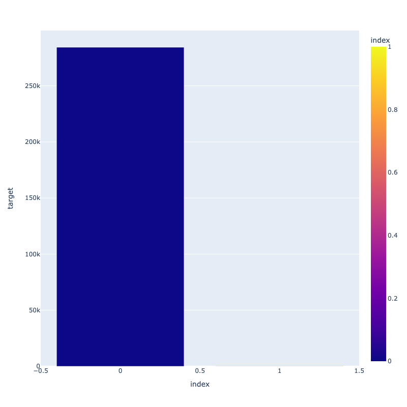

# The distribution of Variables.

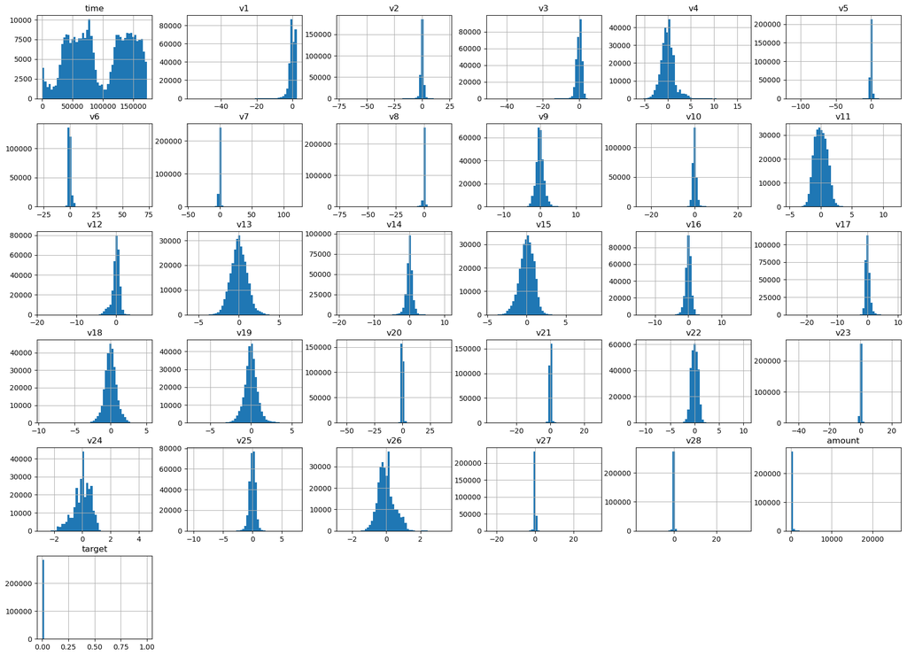

## Methodology

Since this an unsupervised learning problem and we will not be using the labels so we need find a way to measure the performance of the anamoly model. Dimensionality reduction algorithms reduce the dimensionality of data while attempting to minimize the reconstruction error. However, these dimensionality reduction algorithms cannot capture all the information of the original features as they move to a lower dimensional space; therefore, there will be some error as these algorithms reconstruct the reduced feature set back to the original number of dimensions. we will use these errors and make a function to compare them to the original dataframe and measure the score. we make our performance measure as follows:

- We take the difference between the original vs the pca dataframe which we created from pcs components using inverse transformation
- then we transform the difference using min max scaller from 0 to 1 scale
- we can consider this score as probability score and use this against the labels to calculate, precision, recall and threshhold using sklearn precision recall curve metric.
- We will take x number of highest scores as our anomolies
- we can all also calculate average precision score using the average precision score metric.

```
((190820, 29), (190820,), (93987, 29), (93987,))
```

The train data has 330 Fraudulent transaction and 190490 normal transactions

```
0    190490
1       330
Name: target, dtype: int64
```

# Lets create Preprocessing Pipiline

- all our variables are numeric we will standardise data and then as for PCA we must standardise observations.

|  | n__v1 | n__v2 | n__v3 | n__v4 | n__v5 | n__v6 | n__v7 | n__v8 | n__v9 | n__v10 | n__v11 | n__v12 | n__v13 | n__v14 | n__v15 | n__v16 | n__v17 | n__v18 | n__v19 | n__v20 | n__v21 | n__v22 | n__v23 | n__v24 | n__v25 | n__v26 | n__v27 | n__v28 | n__amount |
| --- | --- | --- | --- | --- | --- | --- | --- | --- | --- | --- | --- | --- | --- | --- | --- | --- | --- | --- | --- | --- | --- | --- | --- | --- | --- | --- | --- | --- | --- |
| 142087 | -1.008613 | 1.168013 | 0.203077 | -0.252933 | -0.387030 | -0.051340 | -0.191393 | 0.917626 | -0.220348 | 0.379391 | 0.891953 | 0.652099 | -0.481673 | 0.888920 | 0.511094 | 0.459652 | -0.178769 | -0.131099 | -0.030699 | 0.240351 | -0.230649 | -0.781406 | 0.154163 | -0.584578 | -0.161870 | 0.232116 | 0.525621 | 0.459397 | -0.301324 |
| 165168 | 0.071848 | 0.664025 | -0.240845 | -0.381091 | 0.694608 | -0.633906 | 0.833474 | -0.132701 | -0.166967 | -0.793682 | -0.490992 | 0.366808 | 0.879055 | -1.245368 | -0.369767 | 0.316392 | 0.393419 | -0.407275 | -0.310150 | 0.099453 | -0.438520 | -1.037593 | 0.145573 | 1.078771 | -0.761303 | 0.221753 | 0.564899 | 0.254973 | -0.342346 |
| 235908 | 0.099163 | -0.387383 | -0.945009 | -1.493663 | -0.092322 | -0.878326 | 1.252531 | -0.564372 | -2.760963 | 0.979945 | -0.734286 | -0.940293 | 0.749094 | 0.176712 | -1.084605 | -2.049873 | 1.119388 | -0.424709 | 0.039325 | 0.136822 | 0.597949 | 2.047828 | 0.533608 | 1.885871 | -0.949325 | 0.195840 | 0.394576 | 0.789716 | 0.507010 |
| 148255 | 0.015486 | 0.519611 | 0.193472 | -0.418969 | 0.316777 | -0.774851 | 0.816615 | -0.154107 | -0.060485 | -0.393037 | -0.838072 | 0.229399 | 0.138905 | 0.095691 | -0.404080 | -0.180757 | -0.428453 | -1.022053 | -0.193808 | -0.038190 | -0.336778 | -0.738483 | 0.127711 | -0.026519 | -0.955999 | 0.297594 | 0.620507 | 0.285961 | -0.333753 |
| 145672 | 0.009053 | 0.524138 | 0.175338 | -0.335413 | 0.761346 | 0.501074 | 0.266188 | 0.187765 | -0.186259 | -0.837330 | 0.231244 | 0.693028 | 1.261985 | -1.542311 | -0.324732 | 1.234117 | -0.316896 | 1.377317 | 0.854111 | 0.109213 | -0.199423 | -0.454902 | 0.047231 | -0.725277 | -2.181428 | -0.147735 | 0.586351 | 0.739459 | -0.337806 |

## PCA custom class

- We create a Custom Transformer which will give us labels on the basis of top 350 highest anomoly score using our performace score function
- this will be added in predict method.

# Lets define Evaluation Function to measure the recall, precision and roc_auc score

# Define our PCA model pipeline and see if it works fine with custom Transformer

```
Pipeline(steps=[('preprocess',
                 ColumnTransformer(transformers=[('n',
                                                  Pipeline(steps=[('std',
                                                                   StandardScaler()),
                                                                  ('impute',
                                                                   KNNImputer())]),
                                                  Index(['v1', 'v2', 'v3', 'v4', 'v5', 'v6', 'v7', 'v8', 'v9', 'v10', 'v11',
       'v12', 'v13', 'v14', 'v15', 'v16', 'v17', 'v18', 'v19', 'v20', 'v21',
       'v22', 'v23', 'v24', 'v25', 'v26', 'v27', 'v28', 'amount'],
      dtype='object'))])),
                ('model',
                 pca_anom(estimator=PCA(n_components=29, random_state=2018),
                          top_x=350))])
```

|  | pca0 | pca1 | pca2 | pca3 | pca4 | pca5 | pca6 | pca7 | pca8 | pca9 | pca10 | pca11 | pca12 | pca13 | pca14 | pca15 | pca16 | pca17 | pca18 | pca19 | pca20 | pca21 | pca22 | pca23 | pca24 | pca25 | pca26 | pca27 | pca28 |
| --- | --- | --- | --- | --- | --- | --- | --- | --- | --- | --- | --- | --- | --- | --- | --- | --- | --- | --- | --- | --- | --- | --- | --- | --- | --- | --- | --- | --- | --- |
| 142087 | -0.503552 | -0.086557 | 0.078180 | 0.126792 | -0.584275 | 0.205438 | -0.338339 | 0.301065 | 0.277474 | -0.326303 | 0.129312 | 0.625587 | -0.589936 | 1.110826 | -0.613716 | 0.206283 | 0.647110 | 0.469355 | -0.617997 | -0.035442 | -0.274916 | 0.403849 | -1.131572 | 0.534247 | 0.506733 | 0.491447 | -1.164396 | -0.262446 | -0.082420 |
| 165168 | -0.445917 | -0.295530 | -0.008904 | 0.328010 | 0.591009 | 0.274222 | 1.074437 | 0.179167 | 0.291048 | 0.884476 | -0.755596 | -0.313761 | -0.770876 | -1.111460 | -0.231645 | -0.408441 | -1.469363 | 0.413926 | -0.430565 | -0.612094 | 0.312883 | -0.148244 | -0.611249 | -0.136882 | -0.126312 | 0.857455 | -0.303929 | -0.105879 | 0.042523 |
| 235908 | 0.896149 | -0.289270 | -0.568506 | -0.213853 | 0.772360 | -0.916064 | -0.826229 | -1.543692 | -0.180750 | 1.543498 | -2.307194 | 0.847058 | -0.623454 | -1.268817 | -0.570688 | 2.311289 | -1.469729 | 0.404492 | 0.542410 | 1.540824 | -0.153559 | 0.139862 | 1.148263 | -1.707982 | -1.496720 | -0.135309 | -0.550657 | -0.127613 | 0.150344 |
| 148255 | -0.418133 | -0.359931 | -0.092716 | 0.091789 | -0.325522 | 0.539763 | -0.005340 | 0.631961 | 0.437864 | 0.188399 | -0.523586 | -0.853044 | -0.115711 | -0.720514 | -0.651368 | 0.436623 | -0.990073 | 0.117838 | -0.525740 | 0.082468 | 0.317526 | 0.196801 | -0.800332 | -0.439747 | -0.188850 | 0.800011 | -0.290804 | -0.164921 | 0.053739 |
| 145672 | -0.452670 | -0.122389 | 0.055489 | 0.482373 | 0.428815 | 0.453595 | 1.774697 | 0.222596 | -0.215380 | 1.321750 | -0.540286 | -0.297360 | 0.915669 | 1.534018 | -0.618697 | -1.442722 | -1.529420 | 0.225133 | -0.524002 | -0.002704 | -0.005569 | -1.152543 | -0.617781 | -0.312699 | 0.493600 | 0.346001 | -0.893674 | -0.111020 | 0.052034 |